# Лабораторна робота № 6. Побудова моделей класифікації ІІ. Пакет tidymodels

Barbir Vladyslav

2025-11-18

**Мета:** *Засвоєння базових принципів, знайомство з інструментами та набуття навичок побудови, eкспорту та імпорту моделей класифікації на рівні технології на основі статистичного підходу та моделей машинного навчання засобами мови програмування R та за допомогою універсального інтерфейсу доступа до функцій машинного навчання пакету `tidymodels`.*

## Хід роботи

### Виконання завдання

#### **Підготовка середовища та розвідувальний аналіз даних**

Спочатку завантажимо всі необхідні бібліотеки та дані.

```r
library(tidymodels)
library(tidyverse)
library(mlbench)
library(DBI)
library(RSQLite)
library(ranger)
```

```r
library(corrplot)
library(patchwork)
```

Завантажимо та проведемо короткий розвідувальний аналіз даних (`EDA`).

```r
data(PimaIndiansDiabetes)
diabetes_orig <- as_tibble(PimaIndiansDiabetes)

glimpse(diabetes_orig)
```

```
## Rows: 768
## Columns: 9
## $ pregnant <dbl> 6, 1, 8, 1, 0, 5, 3, 10, 2, 8, 4, 10, 10, 1, 5, 7, 0, 7, 1, 1…
## $ glucose  <dbl> 148, 85, 183, 89, 137, 116, 78, 115, 197, 125, 110, 168, 139,…
## $ pressure <dbl> 72, 66, 64, 66, 40, 74, 50, 0, 70, 96, 92, 74, 80, 60, 72, 0,…
## $ triceps  <dbl> 35, 29, 0, 23, 35, 0, 32, 0, 45, 0, 0, 0, 0, 23, 19, 0, 47, 0…
## $ insulin  <dbl> 0, 0, 0, 94, 168, 0, 88, 0, 543, 0, 0, 0, 0, 846, 175, 0, 230…
## $ mass     <dbl> 33.6, 26.6, 23.3, 28.1, 43.1, 25.6, 31.0, 35.3, 30.5, 0.0, 37…
## $ pedigree <dbl> 0.627, 0.351, 0.672, 0.167, 2.288, 0.201, 0.248, 0.134, 0.158…
## $ age      <dbl> 50, 31, 32, 21, 33, 30, 26, 29, 53, 54, 30, 34, 57, 59, 51, 3…
## $ diabetes <fct> pos, neg, pos, neg, pos, neg, pos, neg, pos, pos, neg, pos, n…
```

```r
summary(diabetes_orig)
```

```
##     pregnant         glucose         pressure         triceps
##  Min.   : 0.000   Min.   :  0.0   Min.   :  0.00   Min.   : 0.00
##  1st Qu.: 1.000   1st Qu.: 99.0   1st Qu.: 62.00   1st Qu.: 0.00
##  Median : 3.000   Median :117.0   Median : 72.00   Median :23.00
##  Mean   : 3.845   Mean   :120.9   Mean   : 69.11   Mean   :20.54
##  3rd Qu.: 6.000   3rd Qu.:140.2   3rd Qu.: 80.00   3rd Qu.:32.00
##  Max.   :17.000   Max.   :199.0   Max.   :122.00   Max.   :99.00
##     insulin           mass          pedigree           age        diabetes
##  Min.   :  0.0   Min.   : 0.00   Min.   :0.0780   Min.   :21.00   neg:500
##  1st Qu.:  0.0   1st Qu.:27.30   1st Qu.:0.2437   1st Qu.:24.00   pos:268
##  Median : 30.5   Median :32.00   Median :0.3725   Median :29.00
##  Mean   : 79.8   Mean   :31.99   Mean   :0.4719   Mean   :33.24
##  3rd Qu.:127.2   3rd Qu.:36.60   3rd Qu.:0.6262   3rd Qu.:41.00
##  Max.   :846.0   Max.   :67.10   Max.   :2.4200   Max.   :81.00
```

```r
diabetes_processed <- diabetes_orig %>%
  mutate(across(c(glucose, pressure, triceps, insulin, mass), ~na_if(., 0)))

colSums(is.na(diabetes_processed))
```

```
## pregnant  glucose pressure  triceps  insulin     mass pedigree      age
##        0        5       35      227      374       11        0        0
## diabetes
##        0
```

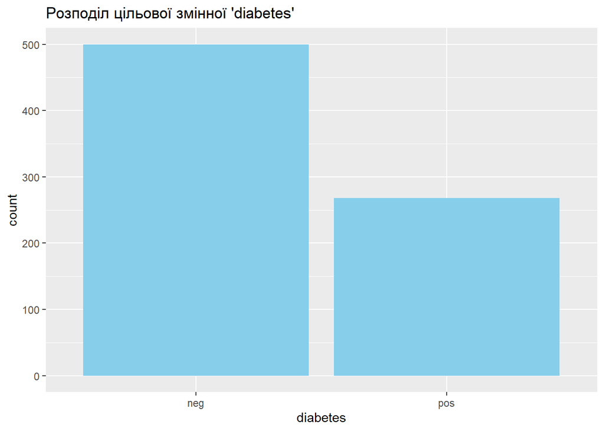

```r
ggplot(diabetes_processed, aes(x = diabetes)) +
  geom_bar(fill = "skyblue") +
  labs(title = "Розподіл цільової змінної 'diabetes'")
```

#### **Побудова моделі Випадкового Лісу**

- **Крок 1: Розділення даних**

Розділимо дані на тренувальну (`training`) та тестову (`testing`) вибірки для об’єктивної оцінки моделі.

```r
set.seed(123)
diabetes_split <- initial_split(diabetes_processed, prop = 0.75, strata = diabetes)

diabetes_train <- training(diabetes_split)
diabetes_test <- testing(diabetes_split)
```

- **Крок 2: Створення “рецепту” для попередньої обробки**

Рецепт (`recipe`) визначає кроки обробки даних, які будуть застосовані до тренувальної та тестової вибірок. Ми заповнимо пропущені значення (`impute`) та нормалізуємо числові предиктори.

```r
diabetes_recipe <- recipe(diabetes ~ ., data = diabetes_train) %>%
  step_impute_knn(all_predictors()) %>%
  step_normalize(all_numeric_predictors())

summary(prep(diabetes_recipe))
```

| variable | type | role | source |
| --- | --- | --- | --- |
| pregnant |  | predictor | original |
| glucose |  | predictor | original |
| pressure |  | predictor | original |
| triceps |  | predictor | original |
| insulin |  | predictor | original |
| mass |  | predictor | original |
| pedigree |  | predictor | original |
| age |  | predictor | original |
| diabetes |  | outcome | original |

- **Крок 3: Специфікація моделі**

Визначимо тип моделі, яку ми хочемо навчити. У нашому випадку це модель випадкового лісу (`rand_forest`).

```r
rf_spec <- rand_forest(trees = 1000) %>%
  set_engine("ranger", importance = "impurity") %>%
  set_mode("classification")

rf_spec
```

```
## Random Forest Model Specification (classification)
##
## Main Arguments:
##   trees = 1000
##
## Engine-Specific Arguments:
##   importance = impurity
##
## Computational engine: ranger
```

- **Крок 4: Створення робочого процесу (`Workflow`)**

Об’єднаємо рецепт та специфікацію моделі в єдиний об’єкт `workflow`. Це спрощує процес навчання та прогнозування.

```r
rf_workflow <- workflow() %>%
  add_recipe(diabetes_recipe) %>%
  add_model(rf_spec)

rf_workflow
```

```
## ══ Workflow ════════════════════════════════════════════════════════════════════
## Preprocessor: Recipe
## Model: rand_forest()
##
## ── Preprocessor ────────────────────────────────────────────────────────────────
## 2 Recipe Steps
##
## • step_impute_knn()
## • step_normalize()
##
## ── Model ───────────────────────────────────────────────────────────────────────
## Random Forest Model Specification (classification)
##
## Main Arguments:
##   trees = 1000
##
## Engine-Specific Arguments:
##   importance = impurity
##
## Computational engine: ranger
```

- **Крок 5: Навчання моделі**

Тепер “підженемо” (`fit`) наш робочий процес під тренувальні дані.

```r
rf_fit <- rf_workflow %>%
  fit(data = diabetes_train)
```

- **Крок 6: Оцінка моделі**

Оцінимо якість навченої моделі на тестових даних, які вона ще не бачила.

```r
diabetes_preds <- predict(rf_fit, diabetes_test) %>%
  bind_cols(predict(rf_fit, diabetes_test, type = "prob")) %>%
  bind_cols(diabetes_test %>% select(diabetes))

conf_mat(diabetes_preds, truth = diabetes, estimate = .pred_class)
```

```
##           Truth
## Prediction neg pos
##        neg 107  23
##        pos  18  44
```

```r
metrics(diabetes_preds, truth = diabetes, estimate = .pred_class)
```

| .metric | .estimator | .estimate |
| --- | --- | --- |
| accuracy | binary | 0.7864583 |
| kap | binary | 0.5217497 |

#### **Експорт та імпорт моделі через реляційну БД**

- **Крок 1: Серіалізація та експорт моделі**

Збережемо навчений об’єкт `rf_fit` у файл, а потім завантажимо його в базу даних `SQLite` як бінарний об’єкт (`BLOB`).

```r
model_blob <- serialize(rf_fit, connection = NULL)

db_conn <- dbConnect(RSQLite::SQLite(), "models_database.db")

dbExecute(db_conn, "
  CREATE TABLE IF NOT EXISTS models (
    model_name TEXT PRIMARY KEY,
    model_object BLOB
  )
")
```

```
## [1] 0
```

```r
dbExecute(db_conn, "DELETE FROM models WHERE model_name = 'pima_random_forest'")
```

```
## [1] 1
```

```r
df_to_write <- tibble(
  model_name = "pima_random_forest",
  model_object = list(model_blob)
)

dbAppendTable(db_conn, "models", df_to_write)
```

```
## [1] 1
```

```r
dbDisconnect(db_conn)

print("Модель 'pima_random_forest' успішно експортована в базу даних (надійним способом).")
```

```
## [1] "Модель 'pima_random_forest' успішно експортована в базу даних (надійним способом)."
```

- **Крок 2: Імпорт моделі та перевірка працездатності**

Тепер виконаємо зворотний процес: завантажимо модель з БД, десеріалізуємо її та перевіримо, чи працює вона.

```r
db_conn <- dbConnect(RSQLite::SQLite(), "models_database.db")

model_retrieved_df <- dbGetQuery(
  db_conn,
  "SELECT model_object FROM models WHERE model_name = 'pima_random_forest'"
)

raw_vector <- model_retrieved_df$model_object[[1]]

imported_rf_model <- unserialize(raw_vector)

dbDisconnect(db_conn)

print("Модель успішно імпортована з бази даних.")
```

```
## [1] "Модель успішно імпортована з бази даних."
```

```r
predict(imported_rf_model, diabetes_test[1, ])
```

| .pred_class |
| --- |
| neg |

#### **Робота з датасетом `palmerpenguins`**

- **Побудова моделей (Випадковий Ліс та Логістична Регресія)**

Повторимо аналогічні кроки для датасету `palmerpenguins`, де ми будемо класифікувати вид пінгвіна.

```r
library(palmerpenguins)
penguins_df <- penguins %>%
  filter(!is.na(sex)) %>%
  select(-island)

set.seed(456)
penguin_split <- initial_split(penguins_df, prop = 0.8, strata = species)
penguin_train <- training(penguin_split)
penguin_test <- testing(penguin_split)

penguin_recipe <- recipe(species ~ ., data = penguin_train) %>%
  step_dummy(all_nominal_predictors()) %>%
  step_normalize(all_numeric_predictors())

rf_spec_pen <- rand_forest(trees = 500) %>%
  set_engine("ranger") %>%
  set_mode("classification")

log_reg_spec <- multinom_reg() %>%
  set_engine("nnet") %>%
  set_mode("classification")

rf_workflow_pen <- workflow() %>% add_recipe(penguin_recipe) %>% add_model(rf_spec_pen)
log_reg_workflow <- workflow() %>% add_recipe(penguin_recipe) %>% add_model(log_reg_spec)

rf_fit_pen <- fit(rf_workflow_pen, data = penguin_train)
log_reg_fit <- fit(log_reg_workflow, data = penguin_train)

preds_rf_pen <- predict(rf_fit_pen, penguin_test) %>%
  bind_cols(penguin_test %>% select(species))
metrics(preds_rf_pen, truth = species, estimate = .pred_class)
```

| .metric | .estimator | .estimate |
| --- | --- | --- |
| accuracy | multiclass | 1 |
| kap | multiclass | 1 |

```r
preds_log_reg <- predict(log_reg_fit, penguin_test) %>%
  bind_cols(penguin_test %>% select(species))
metrics(preds_log_reg, truth = species, estimate = .pred_class)
```

| .metric | .estimator | .estimate |
| --- | --- | --- |
| accuracy | multiclass | 1 |
| kap | multiclass | 1 |

- **Експорт моделей penguins**

Збережемо обидві моделі в ту саму базу даних, але під різними іменами.

```r
rf_blob_pen <- serialize(rf_fit_pen, connection = NULL)
log_reg_blob_pen <- serialize(log_reg_fit, connection = NULL)

df_to_write_pen <- tibble::tibble(
  model_name = c("penguins_random_forest", "penguins_logistic_regression"),
  model_object = list(rf_blob_pen, log_reg_blob_pen) # <-- Пакуємо бінарні дані у список
)

db_conn <- dbConnect(RSQLite::SQLite(), "models_database.db")

dbExecute(db_conn, "DELETE FROM models WHERE model_name = 'penguins_random_forest'")
```

```
## [1] 0
```

```r
dbExecute(db_conn, "DELETE FROM models WHERE model_name = 'penguins_logistic_regression'")
```

```
## [1] 0
```

```r
dbAppendTable(db_conn, "models", df_to_write_pen)
```

```
## [1] 2
```

```r
dbDisconnect(db_conn)

print("Моделі для датасету penguins успішно експортовані.")
```

```
## [1] "Моделі для датасету penguins успішно експортовані."
```

- **Імпорт моделей penguins**

```r
db_conn <- dbConnect(RSQLite::SQLite(), "models_database.db")

retrieved_df_pen <- dbGetQuery(
  db_conn,
  "SELECT model_object FROM models WHERE model_name = 'penguins_random_forest'"
)

dbDisconnect(db_conn)

raw_vector_pen <- retrieved_df_pen$model_object[[1]]

imported_penguin_model <- unserialize(raw_vector_pen)

print("Модель 'penguins_random_forest' успішно імпортована.")
```

```
## [1] "Модель 'penguins_random_forest' успішно імпортована."
```

```r
predict(imported_penguin_model, penguin_test[1:5, ])
```

| .pred_class |
| --- |
| Adelie |
| Adelie |
| Adelie |
| Adelie |
| Adelie |

## References

1. James, G., Witten, D., Hastie, T., & Tibshirani, R. (2023). *An Introduction to Statistical Learning: with Applications in R (3rd ed.)*. Springer.
2. Wickham, H., & Grolemund, G. (2017). *R for Data Science: Import, Tidy, Transform, Visualize, and Model Data*. O’Reilly Media.
3. Kuhn, M., & Silge, J. (2022). *Tidy Modeling with R*. O’Reilly Media.
4. Han, J., Pei, J., & Kamber, M. (2022). *Data Mining: Concepts and Techniques (4th ed.)*. Morgan Kaufmann.